# Project Foundations for Data Science: FoodHub Data Analysis

**Marks: 60**

### Context

The number of restaurants in New York is increasing day by day. Lots of students and busy professionals rely on those restaurants due to their hectic lifestyles. Online food delivery service is a great option for them. It provides them with good food from their favorite restaurants. A food aggregator company FoodHub offers access to multiple restaurants through a single smartphone app.

The app allows the restaurants to receive a direct online order from a customer. The app assigns a delivery person from the company to pick up the order after it is confirmed by the restaurant. The delivery person then uses the map to reach the restaurant and waits for the food package. Once the food package is handed over to the delivery person, he/she confirms the pick-up in the app and travels to the customer's location to deliver the food. The delivery person confirms the drop-off in the app after delivering the food package to the customer. The customer can rate the order in the app. The food aggregator earns money by collecting a fixed margin of the delivery order from the restaurants.

### Objective

The food aggregator company has stored the data of the different orders made by the registered customers in their online portal. They want to analyze the data to get a fair idea about the demand of different restaurants which will help them in enhancing their customer experience. Suppose you are hired as a Data Scientist in this company and the Data Science team has shared some of the key questions that need to be answered. Perform the data analysis to find answers to these questions that will help the company to improve the business.

### Data Description

The data contains the different data related to a food order. The detailed data dictionary is given below.

### Data Dictionary

- order_id: Unique ID of the order
- customer_id: ID of the customer who ordered the food
- restaurant_name: Name of the restaurant
- cuisine_type: Cuisine ordered by the customer
- cost: Cost of the order
- day_of_the_week: Indicates whether the order is placed on a weekday or weekend (The weekday is from Monday to Friday and the weekend is Saturday and Sunday)
- rating: Rating given by the customer out of 5
- food_preparation_time: Time (in minutes) taken by the restaurant to prepare the food. This is calculated by taking the difference between the timestamps of the restaurant's order confirmation and the delivery person's pick-up confirmation.
- delivery_time: Time (in minutes) taken by the delivery person to deliver the food package. This is calculated by taking the difference between the timestamps of the delivery person's pick-up confirmation and drop-off information

### Let us start by importing the required libraries

```python
# import libraries for data manipulation
import numpy as np
import pandas as pd

# import libraries for data visualization
import matplotlib.pyplot as plt
import seaborn as sns
import plotly.express as px

# import to display HTML
from IPython.display import display, HTML
```

```python
from google.colab import drive
drive.mount('/content/drive')
```

```python
# ignore warnings
import warnings
warnings.filterwarnings('ignore')
```

```python
# palette used in visualizations
palette = 'pastel'
```

### Understanding the structure of the data

```python
# read the data
df = pd.read_csv('/content/drive/MyDrive/Python Course/foodhub_order.csv')
# head returns the first 5 rows
df.head()
```

|  | order_id | customer_id | restaurant_name | cuisine_type | cost_of_the_order | day_of_the_week | rating | food_preparation_time | delivery_time |
| --- | --- | --- | --- | --- | --- | --- | --- | --- | --- |
| 0 | 1477147 | 337525 | Hangawi | Korean | 30.75 | Weekend | Not given | 25 | 20 |
| 1 | 1477685 | 358141 | Blue Ribbon Sushi Izakaya | Japanese | 12.08 | Weekend | Not given | 25 | 23 |
| 2 | 1477070 | 66393 | Cafe Habana | Mexican | 12.23 | Weekday | 5 | 23 | 28 |
| 3 | 1477334 | 106968 | Blue Ribbon Fried Chicken | American | 29.20 | Weekend | 3 | 25 | 15 |
| 4 | 1478249 | 76942 | Dirty Bird to Go | American | 11.59 | Weekday | 4 | 25 | 24 |

#### Observations:

The DataFrame has 9 columns as mentioned in the Data Dictionary. Data in each row corresponds to a single order placed by a customer.

### **Question 1:** How many rows and columns are present in the data? [0.5 mark]

```python
# shape returns (rows, cols)
df.shape
```

```
(1898, 9)
```

### **Question 2:** What are the datatypes of the different columns in the dataset? (The info() function can be used) [0.5 mark]

```python
# info() prints a concise summary of the DataFrame
df.info()
```

```
<class 'pandas.core.frame.DataFrame'>
RangeIndex: 1898 entries, 0 to 1897
Data columns (total 9 columns):
 #   Column                 Non-Null Count  Dtype
---  ------                 --------------  -----
 0   order_id               1898 non-null   int64
 1   customer_id            1898 non-null   int64
 2   restaurant_name        1898 non-null   object
 3   cuisine_type           1898 non-null   object
 4   cost_of_the_order      1898 non-null   float64
 5   day_of_the_week        1898 non-null   object
 6   rating                 1898 non-null   object
 7   food_preparation_time  1898 non-null   int64
 8   delivery_time          1898 non-null   int64
dtypes: float64(1), int64(4), object(4)
memory usage: 133.6+ KB
```

#### Observations:

- The dataset has no null entries.
- There are several numeric fields, enabling quantitative analysis.
- There are several categorical fields, allowing for aggregation and segmentation.
- Combined, these fields support multivariate analysis across numerical and categorical dimensions.
- Unique identifiers (e.g., order_id and customer_id) allow grouping by order or customer, enabling deeper insights into repeat customer behavior.
- The rating column poses potential challenges:
  - While it has no null values, many entries contain strings that cannot be coerced into numbers, effectively representing hidden nulls.

### **Question 3:** Are there any missing values in the data? If yes, treat them using an appropriate method. [1 mark]

We will create a new column, 'rating_numeric,' to preserve the original 'rating' data while converting it into a numeric format.

This approach ensures the integrity of the original data and enables mathematical analysis and statistical operations on the numeric ratings.

```python
# Key descriptors
rating_uniques = df['rating'].unique()
rating_counts = df['rating'].value_counts()

print(f"There are {df['rating'].nunique()} unique ratings.")
print(f"There are the following observed values in the rating column: {df['rating'].unique()}")
print()
print(rating_counts)
print()

# Treat missing values
rating_not_given_count = rating_counts.get('Not given', 0)
rating_other_count = df['rating'].size - rating_not_given_count
rating_not_given_percentage = (rating_not_given_count / len(df)) * 100

print()
print(f"There are {rating_not_given_count} hidden nulls in the ratings column, represented as 'Not given'.")
print(f"There are {rating_other_count} ratings that have coerceable values.")
print(f"The hidden nulls account for {rating_not_given_percentage:.2f}% of all ratings.")
print()

# Make a copy to preserve original state
df_copy = df.copy()

# Create a new column for numerical ratings
df['rating_numeric'] = pd.to_numeric(df['rating'], errors='coerce')
rating_numeric_uniques = df['rating_numeric'].unique()
rating_numeric_counts = df['rating_numeric'].value_counts()
rating_numeric_nan = df['rating_numeric'].isna().sum()

print(f"After modification, there still are {rating_not_given_count} hidden nulls in the rating column, represented as 'Not given'.")
print(f"After modification, there also are {rating_numeric_nan} NaN nulls in the newly created rating numeric column.")
print()
print(rating_numeric_counts)
```

```
There are 4 unique ratings.
There are the following observed values in the rating column: ['Not given' '5' '3' '4']

rating
Not given    736
5            588
4            386
3            188
Name: count, dtype: int64


There are 736 hidden nulls in the ratings column, represented as 'Not given'.
There are 1162 ratings that have coerceable values.
The hidden nulls account for 38.78% of all ratings.

After modification, there still are 736 hidden nulls in the rating column, represented as 'Not given'.
After modification, there also are 736 NaN nulls in the newly created rating numeric column.

rating_numeric
5.0    588
4.0    386
3.0    188
Name: count, dtype: int64
```

#### Observations:

- Hidden nulls (represented by "Not given") account for nearly 40% of the dataset, which has a significant impact on analysis.
- Treating "Not given" as a separate category is the most suitable approach, as the presence or absence of a rating could provide valuable insights into the customer experience.
- Adding an additional column of `rating_numeric` preserves the current `ratings` column as a categorical value while also allowing for numerical anaylsis of the values.

### **Question 4:** Check the statistical summary of the data. What is the minimum, average, and maximum time it takes for food to be prepared once an order is placed? [2 marks]

```python
food_prep_time_min = df['food_preparation_time'].min()
food_prep_time_max = df['food_preparation_time'].max()
food_prep_time_mean = df['food_preparation_time'].mean()

print('The minimum time for food to be prepared is', food_prep_time_min, 'minutes.')
print('The maximum time for food to be prepared is', food_prep_time_max, 'minutes.')
print('The average time for food to be prepared is', food_prep_time_mean, 'minutes.')
```

```
The minimum time for food to be prepared is 20 minutes.
The maximum time for food to be prepared is 35 minutes.
The average time for food to be prepared is 27.371970495258168 minutes.
```

#### Observations:

- The range of values for food preparation times is relatively narrow, spanning only 15 minutes.
- While the low deviation might limit variability needed for some correlations, a strong relationship with other variables could still exist if a consistent pattern emerges.
- It might be useful to analyze the distribution shape and check for potential outliers to ensure that the summary statistics are not being skewed by unusual values.

### **Question 5:** How many orders are not rated? [1 mark]

```python
# count 'Not given'
count_not_given = df['rating'].value_counts().get('Not given', 0)
print('There are', count_not_given, 'not rated orders.')
```

```
There are 736 not rated orders.
```

#### Observations:

This reinforces previously stated observations.

### Exploratory Data Analysis (EDA)

### **Question 6:** Explore all the variables and provide observations on their distributions. (Generally, histograms, boxplots, countplots, etc. are used for univariate exploration.) [9 marks]

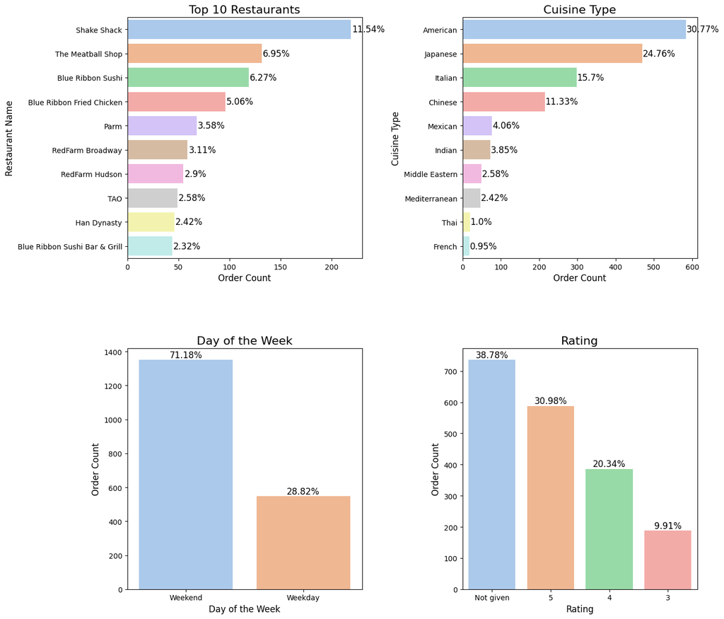

```python
# Create a grid of subplots (2x2)
fig, axes = plt.subplots(2, 2, figsize=(14, 12))

# Helper function for standard vertical bar plot
def plot_categorical_distribution_inline(ax, column, title, xlabel, ylabel, top_n=None):
    """
    Plots a vertical bar chart for a categorical variable on a given axis.
    """
    # Get counts and percentages
    value_counts = df[column].value_counts()
    total = df[column].count()
    if top_n:
        value_counts = value_counts.head(top_n)
    percentages = (value_counts / total * 100).round(2)

    # Prepare data for visualization
    visualization_data = pd.DataFrame({
        column: value_counts.index,
        'Count': value_counts.values,
        'Percentage': percentages.values
    })

    # Plot vertical bar chart
    sns.barplot(
        ax=ax,
        x=visualization_data[column],
        y=visualization_data['Count'],
        palette=palette
    )

    # Annotate the bars
    for bar, count, pct in zip(ax.patches, visualization_data['Count'], visualization_data['Percentage']):
        ax.annotate(
            f"{pct}%",
            (bar.get_x() + bar.get_width() / 2, bar.get_height() + 1),
            ha='center', va='bottom', fontsize=12, color='black'
        )

    # Customize the chart
    ax.set_title(title, fontsize=16)
    ax.set_xlabel(xlabel, fontsize=12)
    ax.set_ylabel(ylabel, fontsize=12)
    ax.tick_params(axis='x')

# Helper function for horizontal bar plot
def plot_categorical_distribution_inline_horizontal(ax, column, title, xlabel, ylabel, top_n=None):
    """
    Plots a horizontal bar chart for a categorical variable on a given axis.
    """
    # Get counts and percentages
    value_counts = df[column].value_counts()
    total = df[column].count()
    if top_n:
        value_counts = value_counts.head(top_n)
    percentages = (value_counts / total * 100).round(2)

    # Prepare data for visualization
    visualization_data = pd.DataFrame({
        column: value_counts.index,
        'Count': value_counts.values,
        'Percentage': percentages.values
    })

    # Plot horizontal bar chart
    sns.barplot(
        ax=ax,
        y=visualization_data[column],
        x=visualization_data['Count'],
        palette=palette,
        orient='h'
    )

    # Annotate the bars
    for bar, count, pct in zip(ax.patches, visualization_data['Count'], visualization_data['Percentage']):
        ax.annotate(
            f"{pct}%",
            (bar.get_width() + 1, bar.get_y() + bar.get_height() / 2),
            ha='left', va='center', fontsize=12, color='black'
        )

    # Customize the chart
    ax.set_title(title, fontsize=16)
    ax.set_xlabel(xlabel, fontsize=12)
    ax.set_ylabel(ylabel, fontsize=12)

# Plot each variable
plot_categorical_distribution_inline_horizontal(axes[0, 0], 'restaurant_name', "Top 10 Restaurants", "Order Count", "Restaurant Name", top_n=10)
plot_categorical_distribution_inline_horizontal(axes[0, 1], 'cuisine_type', "Cuisine Type", "Order Count", "Cuisine Type", top_n=10)
plot_categorical_distribution_inline(axes[1, 0], 'day_of_the_week', "Day of the Week", "Day of the Week", "Order Count")
plot_categorical_distribution_inline(axes[1, 1], 'rating', "Rating", "Rating", "Order Count")

# Adjust layout to prevent overlap and add space between rows
plt.tight_layout()
plt.subplots_adjust(hspace=0.375)

# Display the plots
plt.show()
```

```
Summary Statistics for 'cost_of_the_order':
Mean: 16.50
Median: 14.14
Standard Deviation: 7.48

Analyzing 'cost_of_the_order' for the entire dataset...
```

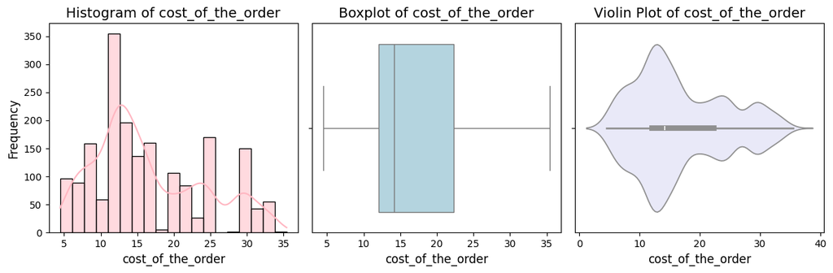

```
Analyzing values within range (11.0, 13.0) for 'cost_of_the_order'...

Number of occurrences in range (11.0, 13.0): 405
Summary Statistics for 'cost_of_the_order' in range (11.0, 13.0):
Mean: 12.23
Median: 12.18
Standard Deviation: 0.34
```

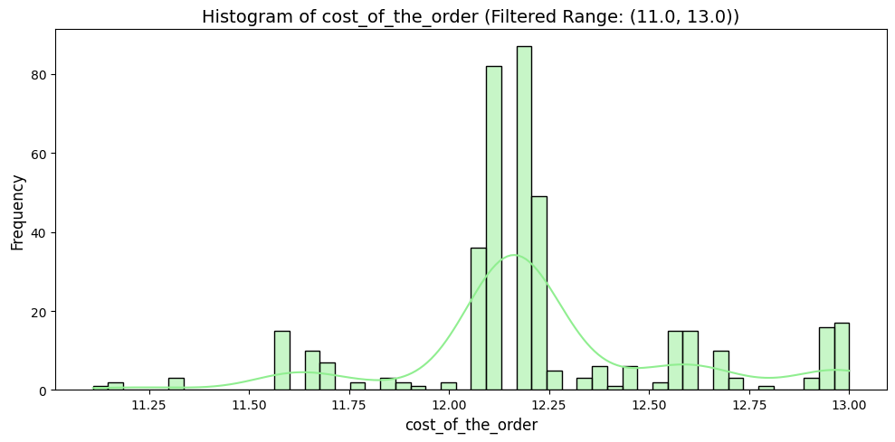

```python
def analyze_cost_of_the_order(focus_range=None):
    """
    Analyzes the 'cost_of_the_order' variable in the dataset.
    Provides a histogram, boxplot, and violin plot for the entire variable.
    Optionally highlights data within a specified range and performs a deeper analysis.

    Args:
    - focus_range (tuple, optional): A tuple specifying a range (min, max) for further analysis.
    """

    # Summary statistics for the filtered data
    mean_val = df['cost_of_the_order'].mean()
    median_val = df['cost_of_the_order'].median()
    std_dev = df['cost_of_the_order'].std()
    print(f"Summary Statistics for 'cost_of_the_order':")
    print(f"Mean: {mean_val:.2f}")
    print(f"Median: {median_val:.2f}")
    print(f"Standard Deviation: {std_dev:.2f}\n")

    # General analysis
    print(f"Analyzing 'cost_of_the_order' for the entire dataset...\n")
    plt.figure(figsize=(12, 4))

    # Histogram
    plt.subplot(1, 3, 1)
    sns.histplot(
        df['cost_of_the_order'], kde=True, bins='auto', color='lightpink'
    )
    plt.title("Histogram of cost_of_the_order", fontsize=14)
    plt.xlabel("cost_of_the_order", fontsize=12)
    plt.ylabel("Frequency", fontsize=12)

    # Boxplot
    plt.subplot(1, 3, 2)
    sns.boxplot(
        x=df['cost_of_the_order'], color='lightblue'
    )
    plt.title("Boxplot of cost_of_the_order", fontsize=14)
    plt.xlabel("cost_of_the_order", fontsize=12)

    # Violin Plot
    plt.subplot(1, 3, 3)
    sns.violinplot(
        x=df['cost_of_the_order'], color='lavender'
    )
    plt.title("Violin Plot of cost_of_the_order", fontsize=14)
    plt.xlabel("cost_of_the_order", fontsize=12)

    plt.tight_layout()
    plt.show()

    # Focused range analysis
    if focus_range:
        print(f"\nAnalyzing values within range {focus_range} for 'cost_of_the_order'...\n")

        # Filter data within the specified range
        filtered_df = df[(df['cost_of_the_order'] >= focus_range[0]) & (df['cost_of_the_order'] <= focus_range[1])]

        # Handle case when no data is found in the range
        if filtered_df.empty:
            print(f"No data found in the range {focus_range}.")
            return

        print(f"Number of occurrences in range {focus_range}: {len(filtered_df)}")

        # Summary statistics for the filtered data
        mean_val = filtered_df['cost_of_the_order'].mean()
        median_val = filtered_df['cost_of_the_order'].median()
        std_dev = filtered_df['cost_of_the_order'].std()
        print(f"Summary Statistics for 'cost_of_the_order' in range {focus_range}:")
        print(f"Mean: {mean_val:.2f}")
        print(f"Median: {median_val:.2f}")
        print(f"Standard Deviation: {std_dev:.2f}\n")

        # Re-plot Histogram for the filtered data
        plt.figure(figsize=(10, 5))
        sns.histplot(
            filtered_df['cost_of_the_order'], kde=True, bins='auto', color='lightgreen'
        )
        plt.title(f"Histogram of cost_of_the_order (Filtered Range: {focus_range})", fontsize=14)
        plt.xlabel("cost_of_the_order", fontsize=12)
        plt.ylabel("Frequency", fontsize=12)
        plt.tight_layout()
        plt.show()

analyze_cost_of_the_order(focus_range=(11.00, 13.00))  # Analyze orders in the $12 range
```

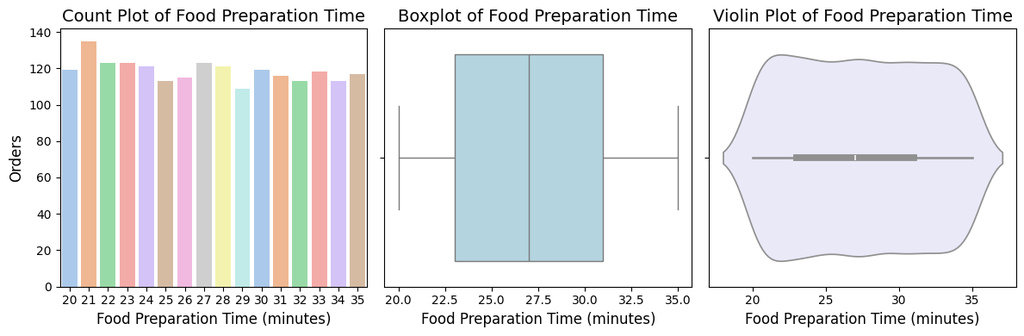

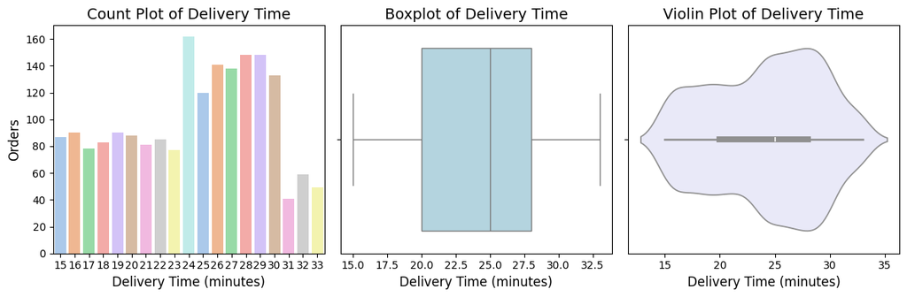

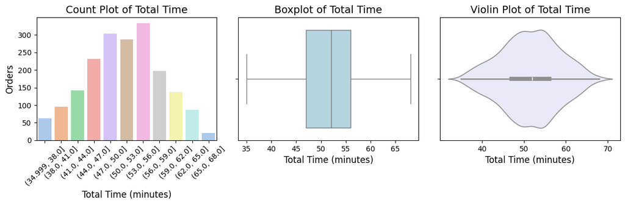

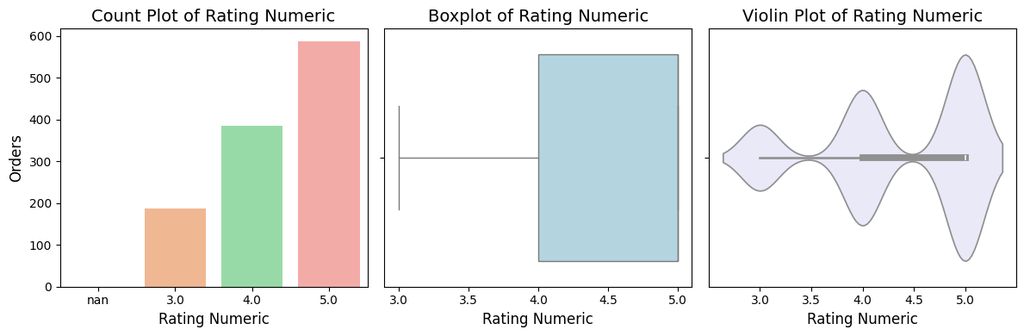

```python
def plot_discrete_variable(column, title_prefix, xlabel, ylabel, order=None, bins=None):
    """
    Plots a count plot, boxplot, and violin plot for a discrete numeric variable.
    Optionally bins the values for the count plot with whole number ranges.

    Args:
    - column (str): The name of the column to analyze.
    - title_prefix (str): Prefix for the plot titles (e.g., 'Food Preparation Time').
    - xlabel (str): Label for the x-axis.
    - ylabel (str): Label for the y-axis.
    - order (list, optional): Order for the count plot. Defaults to None.
    - bins (int, optional): Number of bins to use for the count plot. Defaults to None.
    """
    plt.figure(figsize=(12, 4))

    # Count Plot
    plt.subplot(1, 3, 1)
    if bins:
        # Calculate integer bin edges
        min_val = int(df[column].min())
        max_val = int(df[column].max())
        bin_edges = list(range(min_val, max_val + 1, (max_val - min_val) // bins))
        if bin_edges[-1] < max_val:  # Ensure the last bin includes the max value
            bin_edges.append(max_val)

        # Create binned data for the count plot
        binned_data = pd.cut(df[column], bins=bin_edges, include_lowest=True)
        sns.countplot(
            x=binned_data,
            data=df,
            palette=palette
        )
        plt.xticks(rotation=45)  # Rotate bins for better readability
    else:
        sns.countplot(
            x=column,
            data=df,
            order=order,
            palette=palette
        )
    plt.title(f"Count Plot of {title_prefix}", fontsize=14)
    plt.xlabel(xlabel, fontsize=12)
    plt.ylabel(ylabel, fontsize=12)

    # Boxplot
    plt.subplot(1, 3, 2)
    sns.boxplot(
        x=df[column],
        color='lightblue'
    )
    plt.title(f"Boxplot of {title_prefix}", fontsize=14)
    plt.xlabel(xlabel, fontsize=12)

    # Violin Plot
    plt.subplot(1, 3, 3)
    sns.violinplot(
        x=df[column],
        color='lavender'
    )
    plt.title(f"Violin Plot of {title_prefix}", fontsize=14)
    plt.xlabel(xlabel, fontsize=12)

    plt.tight_layout()
    plt.show()

# Add total time column
df['total_time'] = df['food_preparation_time'] + df['delivery_time']

# Plot each variable
plot_discrete_variable(
    column='food_preparation_time',
    title_prefix='Food Preparation Time',
    xlabel='Food Preparation Time (minutes)',
    ylabel='Orders',
    order=sorted(df['food_preparation_time'].unique())
)

plot_discrete_variable(
    column='delivery_time',
    title_prefix='Delivery Time',
    xlabel='Delivery Time (minutes)',
    ylabel='Orders',
    order=sorted(df['delivery_time'].unique())
)

# Use binning for Total Time with whole-number ranges
plot_discrete_variable(
    column='total_time',
    title_prefix='Total Time',
    xlabel='Total Time (minutes)',
    ylabel='Orders',
    bins=10
)

plot_discrete_variable(
    column='rating_numeric',
    title_prefix='Rating Numeric',
    xlabel='Rating Numeric',
    ylabel='Orders',
    order=sorted(df['rating_numeric'].unique())
)
```

### **Question 7**: Which are the top 5 restaurants in terms of the number of orders received? [1 mark]

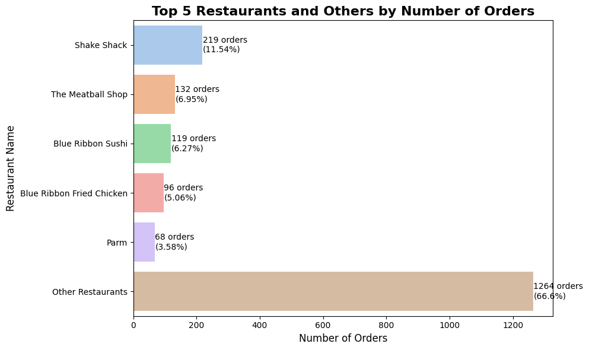

```python
# Find the top 5 restaurants by the number of orders
top_5_restaurants = df['restaurant_name'].value_counts().nlargest(5)

# Calculate the total number of orders
total_orders = df['restaurant_name'].value_counts().sum()

# Calculate the "rest of the restaurants"
other_orders = total_orders - top_5_restaurants.sum()

# Append the "Other Restaurants" category using pd.concat
other_restaurant_series = pd.Series({'Other Restaurants': other_orders})
top_5_restaurants_with_other = pd.concat([top_5_restaurants, other_restaurant_series])

# Calculate percentages for all categories
percentages = (top_5_restaurants_with_other / total_orders * 100).round(2)

# Combine counts and percentages into a single label
labels = [f"{count} orders\n({percent}%)" for count, percent in zip(top_5_restaurants_with_other.values, percentages)]

# Plot the top 5 restaurants + "Other Restaurants"
plt.figure(figsize=(10, 6))
sns.barplot(
    x=top_5_restaurants_with_other.values,
    y=top_5_restaurants_with_other.index,
    palette=palette
)

# Add text labels for counts and percentages
for i, (value, label) in enumerate(zip(top_5_restaurants_with_other.values, labels)):
    plt.text(value + 1, i, label, va='center', fontsize=10)

# Title and labels
plt.title("Top 5 Restaurants and Others by Number of Orders", fontsize=16, fontweight='bold')
plt.xlabel("Number of Orders", fontsize=12)
plt.ylabel("Restaurant Name", fontsize=12)
plt.tight_layout()
plt.show()
```

#### Observations:

- The top 5 restaurants by order volume account for one-third of all orders received.

### **Question 8**: Which is the most popular cuisine on weekends? [1 mark]

```
The most popular cuisine on weekends is American with 415 orders, from 1351 weekend orders.
The most popular cuisine on weekdays is American with 169 orders, from 547 weekday orders.
```

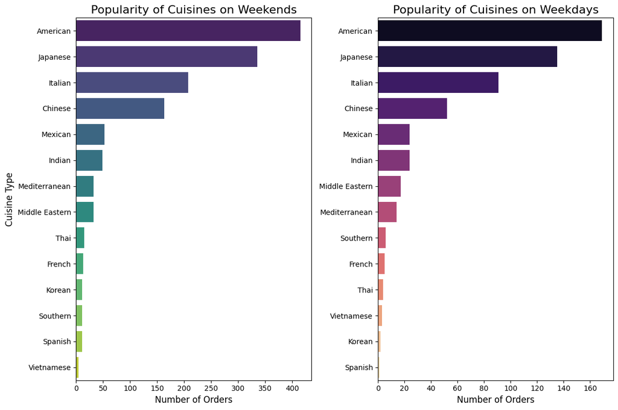

```python
# Filter data for weekend and weekday
weekend_data = df[df['day_of_the_week'] == 'Weekend']
weekday_data = df[df['day_of_the_week'] == 'Weekday']

# Count the number of orders for each cuisine type
cuisine_counts_weekends = weekend_data['cuisine_type'].value_counts()
cuisine_counts_weekdays = weekday_data['cuisine_type'].value_counts()

# Find the most popular cuisine for weekends
most_popular_cuisine_weekends = cuisine_counts_weekends.idxmax()
most_popular_count_weekends = cuisine_counts_weekends.max()

print(f"The most popular cuisine on weekends is {most_popular_cuisine_weekends} "
      f"with {most_popular_count_weekends} orders, from {len(weekend_data)} weekend orders.")

# Find the most popular cuisine for weekdays
most_popular_cuisine_weekdays = cuisine_counts_weekdays.idxmax()
most_popular_count_weekdays = cuisine_counts_weekdays.max()

print(f"The most popular cuisine on weekdays is {most_popular_cuisine_weekdays} "
      f"with {most_popular_count_weekdays} orders, from {len(weekday_data)} weekday orders.")

# Create a 2-column grid for visualization
fig, axes = plt.subplots(1, 2, figsize=(12, 8))

# Weekend cuisine popularity
sns.barplot(x=cuisine_counts_weekends.values, y=cuisine_counts_weekends.index, palette="viridis", ax=axes[0])
axes[0].set_title("Popularity of Cuisines on Weekends", fontsize=16)
axes[0].set_xlabel("Number of Orders", fontsize=12)
axes[0].set_ylabel("Cuisine Type", fontsize=12)

# Weekday cuisine popularity
sns.barplot(x=cuisine_counts_weekdays.values, y=cuisine_counts_weekdays.index, palette="magma", ax=axes[1])
axes[1].set_title("Popularity of Cuisines on Weekdays", fontsize=16)
axes[1].set_xlabel("Number of Orders", fontsize=12)
axes[1].set_ylabel("")  # No ylabel for the second chart to avoid repetition

# Adjust layout
plt.tight_layout()
plt.show()
```

### **Question 9**: What percentage of the orders cost more than 20 dollars? [2 marks]

```python
# Filter for orders costing more than $20
orders_over_20 = df[df['cost_of_the_order'] > 20]

# Calculate the percentage
percentage_over_20 = (len(orders_over_20) / len(df)) * 100

# Print the result
print(f"{percentage_over_20:.2f}% of the orders cost more than $20.")
```

```
29.24% of the orders cost more than $20.
```

#### Observations:

Furthermore, while a substantial proportion of orders (70.76%) fall below $20, the remaining 29.24% of orders, which cost more than $20, represent a significant opportunity for higher-margin revenue. This underscores the importance of targeting high-cost orders through strategic promotions and partnerships with top-performing restaurants.

Aligning operational efficiency with these demand patterns—such as prioritizing the most popular cuisines and maintaining consistency in service quality for high-value orders—can maximize profitability.

### **Question 10**: What is the mean order delivery time? [1 mark]

```python
# Calculate the mean delivery time
delivery_time_mean = df['delivery_time'].mean()
delivery_time_min = df['delivery_time'].min()
delivery_time_max = df['delivery_time'].max()

# Print the result
print(f"The mean order delivery time is {delivery_time_mean:.2f} minutes. The min is {delivery_time_min} and the max is {delivery_time_max}. ")
```

```
The mean order delivery time is 24.16 minutes. The min is 15 and the max is 33.
```

### **Question 11:** The company has decided to give 20% discount vouchers to the top 3 most frequent customers. Find the IDs of these customers and the number of orders they placed. [1 mark]

```python
# Count the number of orders per customer
customer_order_counts = df['customer_id'].value_counts()

# Get the top 3 most frequent customers
top_3_customers = customer_order_counts.nlargest(3)

# Print the results
print("Top 3 Most Frequent Customers:")
for customer_id, order_count in top_3_customers.items():
    print(f"Customer ID: {customer_id}, Number of Orders: {order_count}")
```

```
Top 3 Most Frequent Customers:
Customer ID: 52832, Number of Orders: 13
Customer ID: 47440, Number of Orders: 10
Customer ID: 83287, Number of Orders: 9
```

#### Observations:

- Given that the most frequent customer has only 13 orders, it's likely the customer base is very diverse and fragmented, with most customers placing only a few orders.
- Offering 20% discount vouchers to the top 3 customers will benefit only a very small portion of the customer base.
- This strategy might not significantly impact overall customer retention or sales, given the low order volume of these customers compared to the total

### **Question 12**: Perform a multivariate analysis to explore relationships between the important variables in the dataset. (It is a good idea to explore relations between numerical variables as well as relations between numerical and categorical variables) [10 marks]

```python
def numerical_correlation_analysis(df):
    plt.figure(figsize=(12, 8))

    # Define a pastel colormap for the heatmap
    pastel_cmap = sns.light_palette("seagreen", as_cmap=True)  # Adjust color as desired

    # Compute the correlation matrix
    correlation_matrix = df[['cost_of_the_order', 'food_preparation_time', 'delivery_time', 'rating_numeric']].corr()

    # Plot the heatmap with the pastel colormap
    sns.heatmap(correlation_matrix, annot=True, cmap=pastel_cmap, fmt=".2f", linewidths=0.5)

    # Add a title
    plt.title("Correlation Heatmap of Numerical Variables", fontsize=16)
    plt.show()
```

```python
def categorical_relationship_analysis(df):
    # Heatmap: Day of Week vs. Cuisine Type
    plt.figure(figsize=(12, 8))
    cross_tab = pd.crosstab(df['day_of_the_week'], df['cuisine_type'])
    sns.heatmap(cross_tab, annot=True, fmt="d", cmap="coolwarm")
    plt.title("Heatmap of Day of the Week vs Cuisine Type", fontsize=16)
    plt.xlabel("Cuisine Type", fontsize=12)
    plt.ylabel("Day of the Week", fontsize=12)
    plt.show()
```

```python
def numerical_vs_categorical_analysis_grid(df):
    """
    Display relevant boxplots in a 3-column grid.

    Args:
    - df (pd.DataFrame): The dataset containing the relevant variables.

    Returns:
    - None: Displays the grid of boxplots.
    """
    relevant_pairings = [
        ('delivery_time', 'day_of_the_week'),  # Operational Efficiency
        ('cost_of_the_order', 'cuisine_type'),  # Revenue Distribution
        ('rating_numeric', 'cuisine_type')  # Customer Satisfaction Insights
    ]

    # Create a figure with 1 row and 3 columns
    fig, axes = plt.subplots(1, 3, figsize=(24, 8))  # 1 row, 3 columns

    # Loop through the pairings and axes
    for (num_col, cat_col), ax in zip(relevant_pairings, axes):
        sns.boxplot(data=df, x=cat_col, y=num_col, palette=palette, ax=ax)
        ax.set_title(f"Boxplot of {num_col} by {cat_col}", fontsize=14)
        ax.set_xlabel(cat_col, fontsize=12)
        ax.set_ylabel(num_col, fontsize=12)
        ax.tick_params(axis='x', rotation=45)

    # Adjust layout for better spacing
    plt.tight_layout()
    plt.show()
```

```python
def scatterplots_with_jitter(df):
    """
    Create scatterplots with jitter for delivery_time and food_preparation_time against cost_of_the_order.

    Args:
    - df (pd.DataFrame): The dataset to analyze.

    Returns:
    - None: Displays the scatterplots.
    """
    plot_config = [
        {
            'x_var': 'delivery_time',
            'title': "Scatterplot of Delivery Time vs Cost with Jitter",
            'x_label': "Delivery Time"
        },
        {
            'x_var': 'food_preparation_time',
            'title': "Scatterplot of Food Prep Time vs Cost with Jitter",
            'x_label': "Food Prep Time"
        }
    ]

    # Loop through the configurations and create scatterplots
    for config in plot_config:
        plt.figure(figsize=(12, 6))
        sns.stripplot(
            data=df,
            x=config['x_var'], y='cost_of_the_order',
            hue='rating_numeric',
            palette='deep',
            jitter=True
        )
        plt.title(config['title'], fontsize=16)
        plt.xlabel(config['x_label'], fontsize=12)
        plt.ylabel("Cost of the Order", fontsize=12)
        plt.legend(title="Rating", fontsize=10)
        plt.grid(True, linestyle='--', alpha=0.7)
        plt.tight_layout()
        plt.show()
```

```python
def grouped_insights_grid(df):
    """
    Display barplots for average cost grouped by discrete variables in a 3-column grid.

    Args:
    - df (pd.DataFrame): The dataset to analyze.

    Returns:
    - None: Displays the grid of barplots.
    """
    discrete_vars = ['rating_numeric', 'delivery_time', 'food_preparation_time']

    # Create a figure with 1 row and 3 columns
    fig, axes = plt.subplots(1, 3, figsize=(24, 6))  # 1 row, 3 columns

    # Loop through the variables and axes
    for var, ax in zip(discrete_vars, axes):
        grouped_data = df.groupby(var).agg(
            avg_cost=('cost_of_the_order', 'mean')
        ).reset_index()

        # Barplot for Average Cost
        sns.barplot(data=grouped_data, x=var, y='avg_cost', palette=palette, ax=ax)
        ax.set_title(f"Average Cost by {var.replace('_', ' ').title()}", fontsize=14)
        ax.set_xlabel(var.replace('_', ' ').title(), fontsize=12)
        ax.set_ylabel("Average Cost", fontsize=12)
        ax.tick_params(axis='x', rotation=45)

    # Adjust layout for better spacing
    plt.tight_layout()
    plt.show()
```

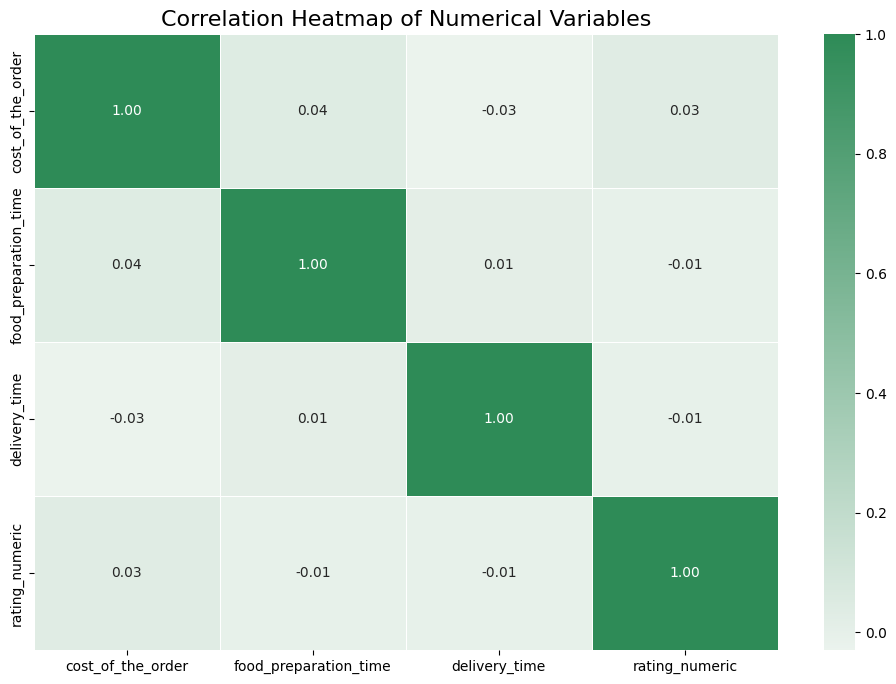

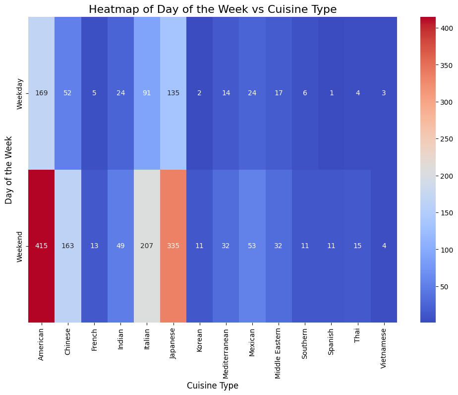

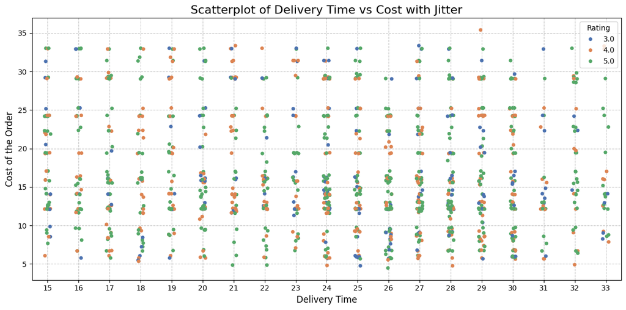

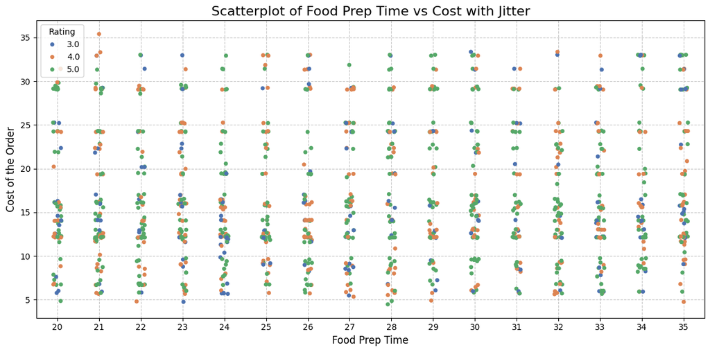

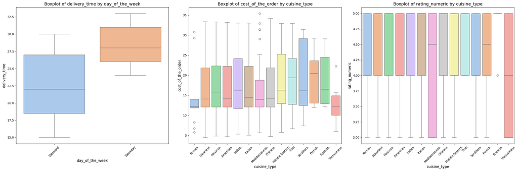

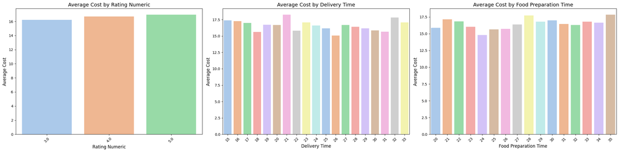

```python
# Call Analysis Functions
numerical_correlation_analysis(df)
categorical_relationship_analysis(df)
scatterplots_with_jitter(df)
numerical_vs_categorical_analysis_grid(df)
grouped_insights_grid(df)
```

```python
def display_top_10_table(df, top_n=10):
    """
    Generate and display a styled table of the top N restaurants by order cost.

    Args:
    - df (pd.DataFrame): The dataset containing order data.
    - top_n (int): Number of top restaurants to display (default: 10).

    Returns:
    - pd.DataFrame: DataFrame with aggregated metrics for the top N restaurants.
    """
    # Aggregate metrics for each restaurant
    restaurant_metrics = df.groupby('restaurant_name').agg(
        avg_cost=('cost_of_the_order', 'mean'),
        avg_delivery_time=('delivery_time', 'mean'),
        avg_food_prep_time=('food_preparation_time', 'mean'),
        avg_rating=('rating_numeric', 'mean'),
        sum_order_cost=('cost_of_the_order', 'sum')
    ).reset_index()

    # Sort by total sum_order_cost to identify top N
    top_restaurants = restaurant_metrics.sort_values(by='sum_order_cost', ascending=False).head(top_n)

    # Round metrics for presentation
    top_restaurants = top_restaurants.round({
        'avg_cost': 2,
        'avg_delivery_time': 2,
        'avg_food_prep_time': 2,
        'avg_rating': 2,
        'sum_order_cost': 2
    })

    # Display styled table in notebook
    styled_table = top_restaurants.style.set_table_styles(
        [{
            'selector': 'thead th',
            'props': [('background-color', '#E6E6FA'), ('font-weight', 'bold'), ('color', 'navy')]
        }]
    ).set_properties(**{
        'text-align': 'center',
        'border': '1px solid black'
    }).set_caption(f"Top {top_n} Restaurants by Order Costs")

    return styled_table

# Display the styled table in the notebook
styled_table = display_top_10_table(df, top_n=10)
styled_table
```

Top 10 Restaurants by Order Costs

|  | restaurant_name | avg_cost | avg_delivery_time | avg_food_prep_time | avg_rating | sum_order_cost |
| --- | --- | --- | --- | --- | --- | --- |
| 136 | Shake Shack | 16.340000 | 24.660000 | 27.950000 | 4.280000 | 3579.530000 |
| 153 | The Meatball Shop | 16.250000 | 24.240000 | 27.180000 | 4.510000 | 2145.210000 |
| 21 | Blue Ribbon Sushi | 16.000000 | 23.940000 | 27.920000 | 4.220000 | 1903.950000 |
| 20 | Blue Ribbon Fried Chicken | 17.320000 | 24.150000 | 27.200000 | 4.330000 | 1662.290000 |
| 109 | Parm | 16.360000 | 25.500000 | 27.310000 | 4.130000 | 1112.760000 |
| 121 | RedFarm Broadway | 16.360000 | 23.150000 | 27.590000 | 4.240000 | 965.130000 |
| 122 | RedFarm Hudson | 16.750000 | 24.200000 | 27.160000 | 4.180000 | 921.210000 |
| 145 | TAO | 17.030000 | 23.160000 | 26.780000 | 4.360000 | 834.500000 |
| 66 | Han Dynasty | 16.420000 | 23.150000 | 27.410000 | 4.430000 | 755.290000 |
| 22 | Blue Ribbon Sushi Bar & Grill | 15.150000 | 23.410000 | 26.300000 | 4.590000 | 666.620000 |

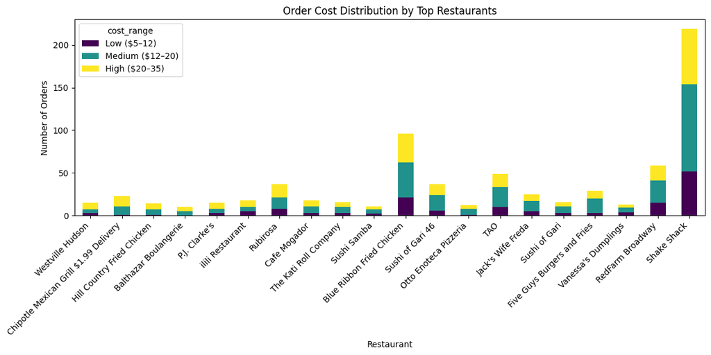

[interactive chart not shown]

```python
# High-Cost Order Analysis Preparation
def analyze_high_cost_orders(df, cost_range=(20, 35)):
    """
    Analyze and visualize restaurants contributing to high-cost orders.

    Args:
    - df: DataFrame containing order data.
    - cost_range: Tuple specifying the range for high-cost orders (default: $20-$35).
    """
    # Filter for high-cost orders
    high_cost_min, high_cost_max = cost_range
    df['cost_range'] = pd.cut(
        df['cost_of_the_order'],
        bins=[0, 12, 20, 35],
        labels=['Low ($5–12)', 'Medium ($12–20)', 'High ($20–35)'],
        right=True
    )

    # Group by restaurant and calculate relevant metrics
    restaurant_high_cost_stats = df.groupby(['restaurant_name', 'cost_range']).size().unstack(fill_value=0)
    restaurant_high_cost_stats['Total Orders'] = restaurant_high_cost_stats.sum(axis=1)
    restaurant_high_cost_stats['High-Cost %'] = (restaurant_high_cost_stats['High ($20–35)'] /
                                                 restaurant_high_cost_stats['Total Orders']) * 100
    restaurant_high_cost_stats['Average Cost'] = df.groupby('restaurant_name')['cost_of_the_order'].mean()

    # Sort by percentage of high-cost orders
    sorted_stats = restaurant_high_cost_stats.sort_values('High-Cost %', ascending=False)
    return sorted_stats

high_cost_stats = analyze_high_cost_orders(df)

def filter_top_restaurants(stats, top_n=20, min_orders=10):
    """
    Filter top restaurants based on high-cost order percentage and total orders.

    Args:
    - stats: DataFrame containing aggregated stats for restaurants.
    - top_n: Number of top restaurants to include (default: 20).
    - min_orders: Minimum total orders required to be included.

    Returns:
    - Filtered DataFrame.
    """
    # Filter restaurants with at least `min_orders`
    filtered_stats = stats[stats['Total Orders'] >= min_orders]

    # Sort by High-Cost % and select top_n
    filtered_stats = filtered_stats.sort_values('High-Cost %', ascending=False).head(top_n)

    return filtered_stats

# Filter for top 20 restaurants with at least 10 orders
filtered_high_cost_stats = filter_top_restaurants(high_cost_stats, top_n=20, min_orders=10)
def visualize_filtered_high_cost_orders(stats):
    """
    Visualize high-cost order analysis for a filtered set of restaurants.

    Args:
    - stats: Filtered DataFrame containing aggregated stats for top restaurants.
    """
    # Stacked bar chart of order distribution
    stats[['Low ($5–12)', 'Medium ($12–20)', 'High ($20–35)']].plot(
        kind='bar', stacked=True, figsize=(12, 6), colormap='viridis'
    )
    plt.title('Order Cost Distribution by Top Restaurants')
    plt.ylabel('Number of Orders')
    plt.xlabel('Restaurant')
    plt.xticks(rotation=45, ha='right')
    plt.tight_layout()
    plt.show()

# Visualize filtered high-cost order stats
visualize_filtered_high_cost_orders(filtered_high_cost_stats)

# Interactive scatterplot with plotly
fig = px.scatter(
    filtered_high_cost_stats,
    x='Average Cost',
    y='High-Cost %',
    size='Total Orders',
    color='High ($20–35)',
    hover_name=filtered_high_cost_stats.index,
    title='High-Cost Orders by Top Restaurants',
    labels={'Average Cost': 'Average Order Cost', 'High-Cost %': 'Percentage of High-Cost Orders'}
)
fig.show()
```

### **Question 13:** The company wants to provide a promotional offer in the advertisement of the restaurants. The condition to get the offer is that the restaurants must have a rating count of more than 50 and the average rating should be greater than 4. Find the restaurants fulfilling the criteria to get the promotional offer. [3 marks]

```
Restaurants eligible for the promotional offer:
               restaurant_name  rating_count  average_rating
20   Blue Ribbon Fried Chicken            64        4.328125
21           Blue Ribbon Sushi            73        4.219178
136                Shake Shack           133        4.278195
153          The Meatball Shop            84        4.511905
```

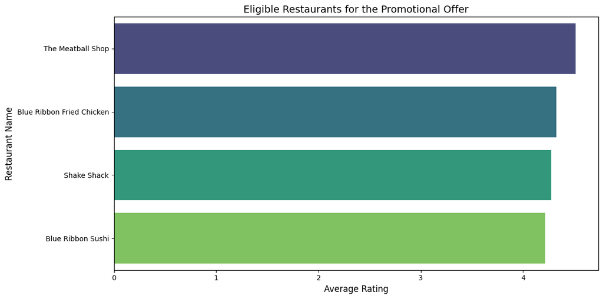

```python
# Group by 'restaurant_name' and calculate the metrics
restaurant_stats = df.groupby('restaurant_name').agg(
    rating_count=('rating_numeric', 'count'),        # Count of valid ratings
    average_rating=('rating_numeric', 'mean')       # Average of ratings
).reset_index()

# Filter the restaurants based on the conditions
eligible_restaurants = restaurant_stats[
    (restaurant_stats['rating_count'] > 50) &
    (restaurant_stats['average_rating'] > 4)
]

# Print the eligible restaurants
print("Restaurants eligible for the promotional offer:")
print(eligible_restaurants)

# Visualize the results
plt.figure(figsize=(12, 6))
sns.barplot(
    data=eligible_restaurants.sort_values('average_rating', ascending=False),
    x='average_rating',
    y='restaurant_name',
    palette="viridis"
)
plt.title("Eligible Restaurants for the Promotional Offer", fontsize=14)
plt.xlabel("Average Rating", fontsize=12)
plt.ylabel("Restaurant Name", fontsize=12)
plt.tight_layout()
plt.show()
```

#### Observations:

- All of the above resturants are also in the top 10 restuarants by measure of order counts. Promoting these restuarnts would make sense based on past customer behaviors.

### **Question 14:** The company charges the restaurant 25% on the orders having cost greater than 20 dollars and 15% on the orders having cost greater than 5 dollars. Find the net revenue generated by the company across all orders. [3 marks]

```python
# Define a function to calculate revenue per order
def calculate_revenue(cost):
    if cost > 20:
        return cost * 0.25  # 25% of cost
    elif cost > 5:
        return cost * 0.15  # 15% of cost
    else:
        return 0  # No charge for cost <= 5

# Apply the function to calculate revenue for each order
df['revenue'] = df['cost_of_the_order'].apply(calculate_revenue)

# Calculate the total revenue
total_revenue = df['revenue'].sum()

# Print the result
print(f"The total revenue generated by the company is ${total_revenue:.2f}.")
```

```
The total revenue generated by the company is $6166.30.
```

#### Observations:

- This reinforces that revenue increases with order cost.

### **Question 15:** The company wants to analyze the total time required to deliver the food. What percentage of orders take more than 60 minutes to get delivered from the time the order is placed? (The food has to be prepared and then delivered.) [2 marks]

```python
# Calculate the total time required for each order
df['total_time'] = df['food_preparation_time'] + df['delivery_time']

# Count the number of orders taking more than 60 minutes
orders_over_60 = df[df['total_time'] > 60]

# Calculate the percentage of orders taking more than 60 minutes
percentage_over_60 = (len(orders_over_60) / len(df)) * 100

print(f"The percentage of orders that take more than 60 minutes is {percentage_over_60:.2f}%.")

max_total_time = df['total_time'].max()
mean_total_time = df['total_time'].mean()

print()
print(f"Maximum Total Time: {max_total_time}")
print(f"Mean (Average) Total Time: {mean_total_time:.2f}")
```

```
The percentage of orders that take more than 60 minutes is 10.54%.

Maximum Total Time: 68
Mean (Average) Total Time: 51.53
```

#### Observations:

- The majority of orders (~89.46%) are delivered within 60 minutes, with a mean total time of 51.53 minutes, indicating an efficient process. The maximum time of 68 minutes suggests only minor delays for a small percentage (10.54%) of orders.
- Investigating the 10.54% of orders exceeding 60 minutes could help identify patterns (e.g., peak times, specific restaurants, or delivery challenges) and further enhance customer satisfaction and operational consistency.

### **Question 16:** The company wants to analyze the delivery time of the orders on weekdays and weekends. How does the mean delivery time vary during weekdays and weekends? [2 marks]

```
Mean Delivery Time:
day_of_the_week
Weekday    28.340037
Weekend    22.470022
Name: delivery_time, dtype: float64
```

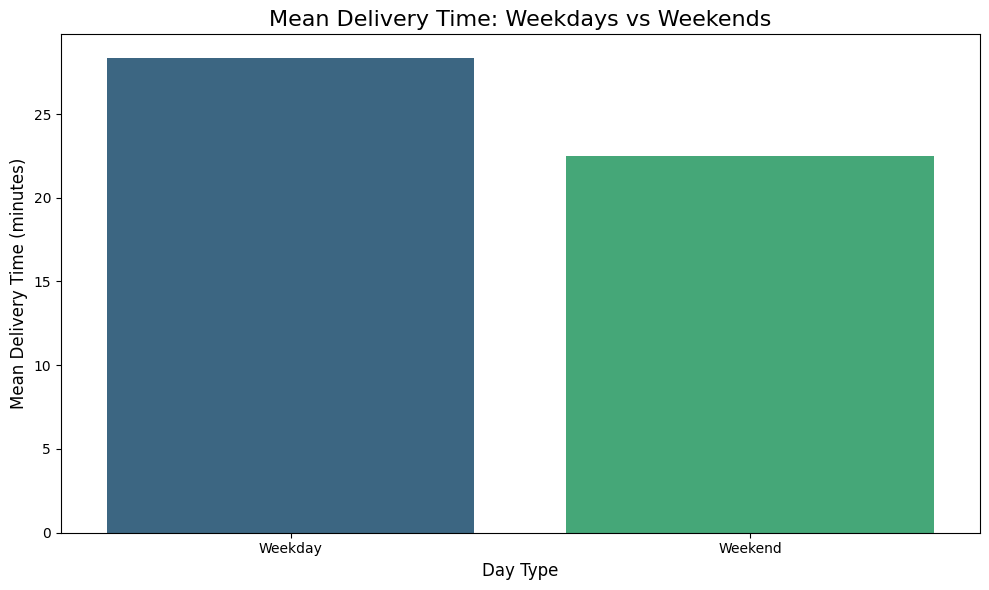

```python
# Calculate mean delivery time for weekdays and weekends
mean_delivery_time = df.groupby('day_of_the_week')['delivery_time'].mean()

# Print the results
print("Mean Delivery Time:")
print(mean_delivery_time)

# Visualize the mean delivery time
import matplotlib.pyplot as plt
import seaborn as sns

plt.figure(figsize=(10, 6))
sns.barplot(x=mean_delivery_time.index, y=mean_delivery_time.values, palette="viridis")
plt.title("Mean Delivery Time: Weekdays vs Weekends", fontsize=16)
plt.xlabel("Day Type", fontsize=12)
plt.ylabel("Mean Delivery Time (minutes)", fontsize=12)
plt.tight_layout()
plt.show()
```

#### Observations:

- Deliveries are quicker on weekends (22.47 minutes) compared to weekdays (28.34 minutes), possibly due to lighter traffic or fewer competing orders.
- Higher weekday delivery times may indicate challenges like traffic or peak-hour demand, highlighting opportunities for improvement.

### **Recommendations**

1. **Improve Long-Tail Order Efficiency**:
   - Investigate and address the 10.54% of orders exceeding 60 minutes to identify and resolve delays in food preparation or delivery. Analyze patterns such as restaurant-specific issues, geographic regions, or peak hours to reduce inefficiencies.
2. **Optimize Weekday Deliveries**:
   - Address weekday-specific bottlenecks by investigating traffic patterns, peak demand times, or resource shortages. Redistribute delivery resources or introduce incentives for off-peak orders to improve weekday performance.
3. **Leverage Popular Price Points**:
   - Focus on optimizing delivery and operational efficiency for orders in the $12 range, as they represent a significant proportion of total orders and revenue.
   - Explore targeted promotions or upselling strategies within this pricing band, encouraging customers to move into higher-cost options.
4. **Collaborate with Top-Contributing Restaurants**:
   - Partner with restaurants driving high-cost orders to create premium packages or deals that encourage more high-value orders.
   - Support restaurants dominating the $12 price range by enhancing operational processes and diversifying offerings to maintain customer loyalty.
   - Integrate these offerings into a loyalty program that rewards customers for frequent high-value purchases, fostering customer retention and incentivizing repeat orders.
5. **Enhance Customer Satisfaction**:
   - Introduce a targeted promotion, such as a discount on a future order or loyalty points, incentivizing customers to leave feedback. This approach not only encourages more ratings but also helps gather valuable insights into customer experiences, enabling data-driven improvements to service quality and satisfaction.
6. **Promote Weekend Offers**:
   - Leverage faster weekend delivery times by promoting premium offers, discounts, or incentives to increase high-cost orders and overall revenue during weekends.